# Class 7: Uber vs Didi: Strategy Implementation

MG106 Strategic Management

José Ignacio González Rojas

j.i.gonzalez-rojas@lse.ac.uk

London School of Economics and Political Science

July 1, 2026

## Uber vs Didi shows why business models do not transfer automatically

### Strategy implementation depends on local assumptions, partners, and regulation

#### Uber’s promise

- App-based matching
- Transparent routes and payments
- Ratings and trust mechanisms
- Flexible supply through drivers

#### The implementation question

- Which parts of the model travelled?
- Which assumptions changed in China?
- What did Didi adapt locally?

The class is about implementation and local adaptation, not generic platform admiration.

## Four questions structure today’s transferability discussion

### Business model, pricing, booking, and China implementation

#### Four questions to explore

1. What is Uber’s innovation?
2. Do you agree with the use of a surge pricing model?
3. Is advance booking inefficient in ride-hailing?
4. Why couldn’t Uber implement its model in China?

Start with the customer pain point, then identify the implementation assumption.

**Task:** 10 minutes in pairs or trios on traditional taxi pain points

## Taxi pain points reveal what Uber’s model had to solve

### Start from the customer experience before naming features

What frustrates customers about traditional taxis?

*Separate uncertainty, trust, payment, availability, and accountability.*

# Uber’s innovation was a coordination system, not just an app

## Traditional taxis created uncertainty, trust, and availability problems

### Common pain points

#### Uncertainty and risk

- Will I find a taxi?
- How long will I wait?
- What route will they take?
- Is the driver trustworthy?

#### System failures

- No recourse for bad service
- Peak hour shortage
- Cash only payments
- Language barriers

Which pain points does the business model solve?

## Uber’s business model coordinated riders and drivers through information

### WHO, WHAT, and HOW

| **Traditional Taxi** | **Uber** |
| --- | --- |
| WHO: Taxi companies | WHO: Riders and drivers coordinated through an app |
| WHAT: Transportation service | WHAT: Real-time matching, visibility, and trust |
| HOW: Own cars, employ drivers | HOW: App, pricing, ratings, payments, and driver supply |

## Uber created value by matching features to taxi pain points

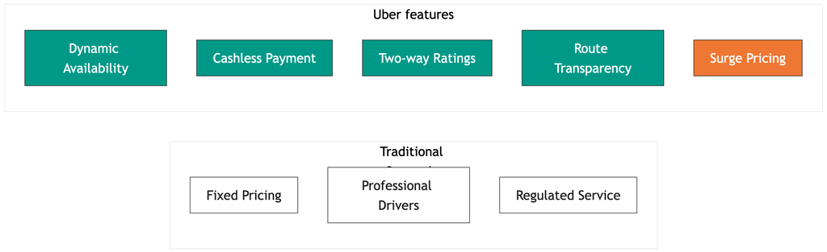

Which pain point matters most for adoption?

# Surge pricing creates efficiency and trust trade-offs

## Surge pricing can increase supply but changes trust perceptions

### The economic logic

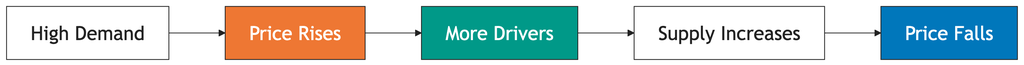

When does price flexibility improve service, and when does it damage trust?

## The ethics question is when efficiency becomes exploitation

### What would you cap, disclose, or redesign?

| Scenario | Efficiency argument | Trust/reputation risk | What would you cap or disclose? |
| --- | --- | --- | --- |
| Bad weather | More drivers may enter | Customers feel punished |  |
| Major event | Supply moves to high demand | Price feels opportunistic |  |
| Emergency/holiday | Availability may improve | Vulnerable customers may be harmed |  |

## Surge Pricing Boundaries

**Discussion boundary**

Surge pricing can improve availability, but it can also damage trust when customers feel vulnerable, surprised, or trapped.

- What information should the rider see before accepting?
- Should there be caps in emergencies or holidays?
- What alternative would solve peak-time shortages?

# Advance booking tests whether efficiency is the only objective

## Real-time and advance booking serve different customer segments

### Efficiency logic must be tested against local needs

#### Real-time matching

- Advance booking may create idle capacity
- 3-5 minute arrival promise
- Dynamic optimisation
- Efficiency prioritised

#### Advance booking

- Airport pickups crucial
- Customer certainty valued
- Serves customers who value certainty
- May fit local customer segments

Is this about efficiency only, or about customer segments and local market understanding?

# Uber’s China problem was implementation across contexts

## Uber’s transferable strengths still needed local fit

### Which assumption failed first in China?

#### Transferable strengths

- App and matching know-how
- Brand recognition
- Technology and operations capabilities
- Access to capital

#### Local conditions

- Maps, payments, and customer habits differed
- Different payment habits
- Pre-booking essential
- Local competitors had major ecosystem backers
- Regulatory and government relationships mattered

## China exhibits point to ecosystem advantage, not only app features

### Market share, subsidies, and BAT backing changed implementation conditions

#### Local market evidence

- Didi/Kuaidi quickly dominated taxi-hailing usage after subsidy battles
- Heavy subsidies made scale and capital commitment central
- Product fit included taxis, pre-booking, and local payments

#### Ecosystem evidence

- Alibaba, Tencent, and Baidu connections mattered for payments, traffic, maps, and data
- Local regulatory relationships and operating knowledge were part of the offer
- Uber’s transferable model faced locally embedded complements

Better app, or better local system?

## Didi’s home advantage combined product fit, partners, and context

### Product fit, partners, and context

#### Product fit

- Included regular taxis
- Pre-booking allowed
- Multiple service tiers
- Local payment integration

#### Local ecosystem

- Major local technology backers
- Regulatory and government relationships
- Local data, maps, and operating knowledge

Home advantage means resources, relationships, and adaptation — not local knowledge alone.

## The implementation gap explains why a good model may not transfer

### Transfer requires adaptation, not just capital and scale

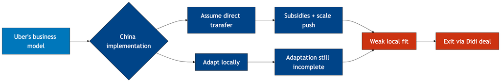

## Implementation determines whether business-model innovation travels

### Lessons for implementation and adaptation

#### Innovation is not enough

- Business model innovation can be powerful
- Context shapes whether it works
- Local adaptation essential
- Implementation determines whether strategy works

#### Local competition is specific

- Network effects can matter
- Local players have advantages
- Access to capital help but don’t guarantee
- Strategic investors matter

## For tomorrow, read Ryanair as a strategic-interaction case

**Ryanair: Dogfight over Europe**

**Read:** Ryanair (A) and (B)

**Questions to consider:**

1. Describe Ryanair’s launch strategy.
2. How did competitors respond?
3. What went wrong?

**Focus:** strategic interaction and competitor response.